# Week04 Assignment

Sophie Kim

March 1, 2016

# 1. The Problem of Distance

Plot recombination fractions (for many values between 0 and 1) against mapping distance

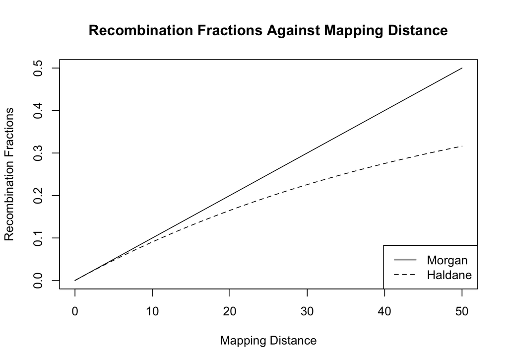

```r
recfrac <- (0:50)/100
cM <- recfrac * 100

plot(x = cM, y = recfrac, xlab = "Mapping Distance", ylab = "Recombination Fractions", main = "Recombination Fractions Against Mapping Distance", type = "l")

lines(x = cM, y = 0.5* (1 - 2.71828^(-2*recfrac)), type = "l", lty = 2)

legend(x = "bottomright", legend = c("Morgan", "Haldane"), lty = c(1,2))
```

# 2. Using Distance

- The code blocks show a table of each gene triplet paired with corresponding frequencies.
- Parental Genotypes were revealed by the genotypes with the greatest number of frequencies.
- Double Recombinant Genotypes were revealed by the genotypes with the least number of frequencies.
- Gene Triplet (allele1_allele1_allele1) is written as (1, 1, 1) for purposes of simplicity

> GeneTriplet1

```r
gameteTable <- read.table("listOfGametes")

table(subset(gameteTable, V2 == "GeneTriplet1")$V1)
```

```
##
## Allele1_Allele1_Allele1 Allele1_Allele1_Allele2 Allele1_Allele2_Allele1
##                     267                      26                      11
## Allele1_Allele2_Allele2 Allele2_Allele1_Allele1 Allele2_Allele1_Allele2
##                     195                     167                      21
## Allele2_Allele2_Allele1 Allele2_Allele2_Allele2
##                      34                     279
```

Parental Genotype: (1, 1, 1), (2, 2, 2)

Double Recombinants: (1, 2, 1), (2, 1, 2)

1. Middle gene: Gene2 (given triplet of (gene1, gene2, gene3) in the data)

–> Gene order: Gene1, Gene2, Gene3

2. Morgan Mapping Distance Calculation

```r
mDist1_12 <- ((195 + 167 + 11 + 21) / 1000 ) * 100

mDist1_23 <- ((26 + 34 + 11 + 21) / 1000 ) * 100

mDist1_13 <- mDist1_12 + mDist1_23

mDist1_12
```

```
## [1] 39.4
```

```r
mDist1_23
```

```
## [1] 9.2
```

```r
mDist1_13
```

```
## [1] 48.6
```

- mDist1_12 represents the Morgan mapping distance between Gene1 and Gene2 in GeneTriplet1 Group
- mDist1_23 represents the Morgan mapping distance between Gene2 and Gene3 in GeneTriplet1 Group
- mDist1_13 represents the Morgan mapping distance between Gene1 and Gene3 in GeneTriplet1 Group
3. Haldane Mapping Distance Calculation

```r
getHaldane <- function(rf) {
  rfValue <- rf/100
  m <- -log(1-2*rfValue)
  mdHaldane <- 50*m
  return(mdHaldane)
}

hDist1_12 <- getHaldane(mDist1_12)
hDist1_13 <- getHaldane(mDist1_13)
hDist1_23 <- getHaldane(mDist1_23)

hDist1_12
```

```
## [1] 77.55845
```

```r
hDist1_13
```

```
## [1] 178.7775
```

```r
hDist1_23
```

```
## [1] 10.16705
```

- hDist1_12 represents the Haldane mapping distance between Gene1 and Gene2 in GeneTriplet1 Group
- hDist1_23 represents the Haldane mapping distance between Gene2 and Gene3 in GeneTriplet1 Group
- hDist1_13 represents the Haldane mapping distance between Gene1 and Gene3 in GeneTriplet1 Group

> GeneTriplet2

```r
table(subset(gameteTable, V2 == "GeneTriplet2")$V1)
```

```
##
## Allele1_Allele1_Allele1 Allele1_Allele1_Allele2 Allele1_Allele2_Allele1
##                     240                     245                       5
## Allele1_Allele2_Allele2 Allele2_Allele1_Allele1 Allele2_Allele1_Allele2
##                       4                       3                       1
## Allele2_Allele2_Allele1 Allele2_Allele2_Allele2
##                     233                     269
```

Parental Genotype: (1, 1, 1), (2, 2, 2)

Double Recombinants: (1, 2, 1), (2, 1, 2)

1. Middle gene: Gene2

–> Gene order: Gene1, Gene2, Gene3

2. Morgan Mapping Distance Calculation

```r
mDist2_12 <- ((3 + 4 +5 + 1) / 1000 ) * 100

mDist2_23 <- ((245 + 233 + 5 + 1) / 1000 ) * 100

mDist2_13 <- mDist2_12 + mDist2_23

mDist2_12
```

```
## [1] 1.3
```

```r
mDist2_23
```

```
## [1] 48.4
```

```r
mDist2_13
```

```
## [1] 49.7
```

- mDist2_12 represents the Morgan mapping distance between Gene1 and Gene2 in GeneTriplet2 Group
- mDist2_23 represents the Morgan mapping distance between Gene2 and Gene3 in GeneTriplet2 Group
- mDist2_13 represents the Morgan mapping distance between Gene1 and Gene3 in GeneTriplet2 Group
3. Haldane Mapping Distance Calculation

```r
hDist2_12 <- getHaldane(mDist2_12)
hDist2_13 <- getHaldane(mDist2_13)
hDist2_23 <- getHaldane(mDist2_23)

hDist2_12
```

```
## [1] 1.317199
```

```r
hDist2_13
```

```
## [1] 255.7998
```

```r
hDist2_23
```

```
## [1] 172.101
```

- hDist2_12 represents the Haldane mapping distance between Gene1 and Gene2 in GeneTriplet2 Group
- hDist2_23 represents the Haldane mapping distance between Gene2 and Gene3 in GeneTriplet2 Group
- hDist2_13 represents the Haldane mapping distance between Gene1 and Gene3 in GeneTriplet2 Group

> GeneTriplet3

```r
table(subset(gameteTable, V2 == "GeneTriplet2")$V1)
```

[output not shown]

Parental Genotype: (1, 1, 1), (2, 2, 2)

Double Recombinants: (1, 2, 1), (2, 1, 2)

1. Middle gene: Gene2

–> Gene order: Gene1, Gene2, Gene3

2. Morgan Mapping Distance Calculation

```r
mDist3_12 <- ((81 + 89 + 19 + 20) / 1000 ) * 100

mDist3_23 <- ((76 + 72 + 19 + 20) / 1000 ) * 100

mDist3_13 <- mDist3_12 + mDist3_23

mDist3_12
```

```
## [1] 20.9
```

```r
mDist3_23
```

```
## [1] 18.7
```

```r
mDist3_13
```

```
## [1] 39.6
```

- mDist3_12 represents the Morgan mapping distance between Gene1 and Gene2 in GeneTriplet3 Group
- mDist3_23 represents the Morgan mapping distance between Gene2 and Gene3 in GeneTriplet3 Group
- mDist3_13 represents the Morgan mapping distance between Gene1 and Gene3 in GeneTriplet3 Group
3. Haldane Mapping Distance Calculation

```r
hDist3_12 <- getHaldane(mDist3_12)
hDist3_13 <- getHaldane(mDist3_13)
hDist3_23 <- getHaldane(mDist3_23)

hDist3_12
```

```
## [1] 27.06424
```

```r
hDist3_13
```

```
## [1] 78.51086
```

```r
hDist3_23
```

```
## [1] 23.42025
```

- hDist3_12 represents the Haldane mapping distance between Gene1 and Gene2 in GeneTriplet3 Group
- hDist3_23 represents the Haldane mapping distance between Gene2 and Gene3 in GeneTriplet3 Group
- hDist3_13 represents the Haldane mapping distance between Gene1 and Gene3 in GeneTriplet3 Group

> GeneTriplet4

```r
table(subset(gameteTable, V2 == "GeneTriplet2")$V1)
```

[output not shown]

Parental Genotype: (1, 1, 1), (2, 2, 2)

1. Middle gene: Gene3

–> Gene order: Gene1, Gene3, Gene2

2. Morgan Mapping Distance Calculation

```r
mDist4_13 <- ((198 + 190 + 37 + 55) / 1000 ) * 100

mDist4_23 <- ((60 + 62 + 37 + 55) / 1000 ) * 100

mDist4_12 <- mDist4_13 + mDist4_23

mDist4_12
```

```
## [1] 69.4
```

```r
mDist4_23
```

```
## [1] 21.4
```

```r
mDist4_13
```

```
## [1] 48
```

- mDist4_12 represents the Morgan mapping distance between Gene1 and Gene2 in GeneTriplet4 Group
- mDist4_23 represents the Morgan mapping distance between Gene2 and Gene3 in GeneTriplet4 Group
- mDist4_13 represents the Morgan mapping distance between Gene1 and Gene3 in GeneTriplet4 Group
3. Haldane Mapping Distance Calculation

```r
hDist4_12 <- getHaldane(mDist4_12)
hDist4_13 <- getHaldane(mDist4_13)
hDist4_23 <- getHaldane(mDist4_23)

hDist4_12
```

```
## [1] NaN
```

```r
hDist4_13
```

```
## [1] 160.9438
```

```r
hDist4_23
```

```
## [1] 27.93081
```

- hDist4_12 represents the Haldane mapping distance between Gene1 and Gene2 in GeneTriplet4 Group
- hDist4_23 represents the Haldane mapping distance between Gene2 and Gene3 in GeneTriplet4 Group
- hDist4_13 represents the Haldane mapping distance between Gene1 and Gene3 in GeneTriplet4 Group

# 3. A More Complex Map

> > Part 1. Calculate the distance between genes for each set of three genes (ie for each individual)
- Read data from text file into variable cMap

```r
cMap <- read.table("gamete_genotyping_project.txt", header = T)
```

> Individual 1

```r
data1 <- subset(cMap, individual_id == 1)

sum1 <- sum(data1$gamete_count)
```

( sum1 stores the total number of gametes for individual1. )

- Parental Genotype: sng/+++
- Double Recombinant Genotype: s+g/+n+
- Middle gene: n
- Gene order: s, n, g

```r
s_n <- (20 + 1 + 30 + 2) / sum1
n_g <- (7 + 1 + 10 + 2) / sum1

s_n
```

```
## [1] 0.2944444
```

```r
n_g
```

```
## [1] 0.1111111
```

```r
data2 <- subset(cMap, individual_id == 2)

sum2 <- sum(data2$gamete_count)
```

( sum2 stores the total number of gametes for individual2. )

- Parental Genotype: n+g/+j+
- Double Recombinant Genotype: +++/njg
- Middle gene: j
- Gene order: n, j, g

```r
n_j <- (4 + 0 + 5 + 1) / sum2
j_g <- (2 + 1 + 1 + 0) / sum2

n_j
```

```
## [1] 0.08130081
```

```r
j_g
```

```
## [1] 0.03252033
```

> Individual 3

```r
data3 <- subset(cMap, individual_id == 3)

sum3 <- sum(data3$gamete_count)
```

( sum3 stores the total number of gametes for individual3. )

- Parental Genotype: ne+/++i
- Double Recombinant Genotype: n++/+ei
- Middle gene: e
- Gene order: n, e, i

```r
n_e <- (6 + 1 + 8 + 0) / sum3
e_i <- (3 + 1 + 4 + 0) / sum3

n_e
```

```
## [1] 0.1315789
```

```r
e_i
```

```
## [1] 0.07017544
```

> Individual 4

```r
data4 <- subset(cMap, individual_id == 4)

sum4 <- sum(data4$gamete_count)
```

( sum4 stores the total number of gametes for individual4. )

- Parental Genotype: s++/+ci
- Double Recombinant Genotype: ++i/sc+
- Middle gene: c
- Gene order: s, c, i

```r
s_c <- (6 + 0 + 5 + 1) / sum4
c_i <- (2 + 0 + 3 + 1) / sum4

s_c
```

```
## [1] 0.06030151
```

```r
c_i
```

```
## [1] 0.03015075
```

> Individual 5

```r
data5 <- subset(cMap, individual_id == 5)

sum5 <- sum(data5$gamete_count)
```

( sum5 stores the total number of gametes for individual5. )

- Parental Genotype: sej/+++
- Double Recombinant Genotype: s+j/+e+
- Middle gene: e
- Gene order: s, e, j

```r
s_e <- (18 + 4 + 20 + 5) / sum5
e_j <- (25 + 4 + 28 + 5) / sum5

s_e
```

```
## [1] 0.1631944
```

```r
e_j
```

```
## [1] 0.2152778
```

> > Part 2. Make a genetic map composed of all seven traits

Gathering information from the data above:

s _ _ _ n _ g

_ _ _ _ n j g

_ _ i e n _ _

s c i _ _ _ _

s _ _ e _ j _

So the complete sequence is : s-c-i-e-n-j-g

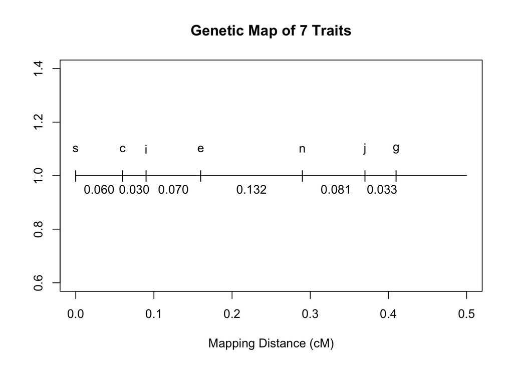

```r
plot(x = c(0,0.5), y = c(1,1), xlab = "Mapping Distance (cM)", ylab = '', main = "Genetic Map of 7 Traits", type = "l")
text(x = 0.00, y = 1.1, labels = "s")
text(x = 0.06, y = 1.1, labels = "c")
text(x = 0.09, y = 1.1, labels = "i")
text(x = 0.16, y = 1.1, labels = "e")
text(x = 0.29, y = 1.1, labels = "n")
text(x = 0.37, y = 1.1, labels = "j")
text(x = 0.41, y = 1.1, labels = "g")

text(x = 0.00, y = 1.0, labels = "|")
text(x = 0.06, y = 1.0, labels = "|")
text(x = 0.09, y = 1.0, labels = "|")
text(x = 0.16, y = 1.0, labels = "|")
text(x = 0.29, y = 1.0, labels = "|")
text(x = 0.37, y = 1.0, labels = "|")
text(x = 0.41, y = 1.0, labels = "|")

text(x = 0.03, y = 0.95, labels = "0.060")
text(x = 0.075, y = 0.95, labels = "0.030")
text(x = 0.125, y = 0.95, labels = "0.070")
text(x = 0.225, y = 0.95, labels = "0.132")
text(x = 0.333, y = 0.95, labels = "0.081")
text(x = 0.392, y = 0.95, labels = "0.033")
```